# Lizard Lake

[Lizard Lake (E206283)](https://governmentofbc.maps.arcgis.com/apps/MapSeries/index.html?appid=a5ffb1bcffad4407b387292f2e55899f) is located at LIZARD LAKE DEEPEST POINT. Report generated: November 25, 2026.

The plot below shows the sampling history at this site. Composite samples are indicated by a vertical line connecting the uppermost and lowermost sampling depths. Triangles (▲) indicate epilimnion (upper layer) samples; solid circles (●) indicate hypolimnion (bottom layer) samples. For lakes less than 10 m deep, a single sample 1 m below the surface represents the epilimnion and one 1 m off the bottom represents the hypolimnion.

To read more about the B.C. Lakes Monitoring Network (BCLMN) go [here](https://www2.gov.bc.ca/gov/content?id=2493EFF1E42747E1904540DA4D2CF9DD).

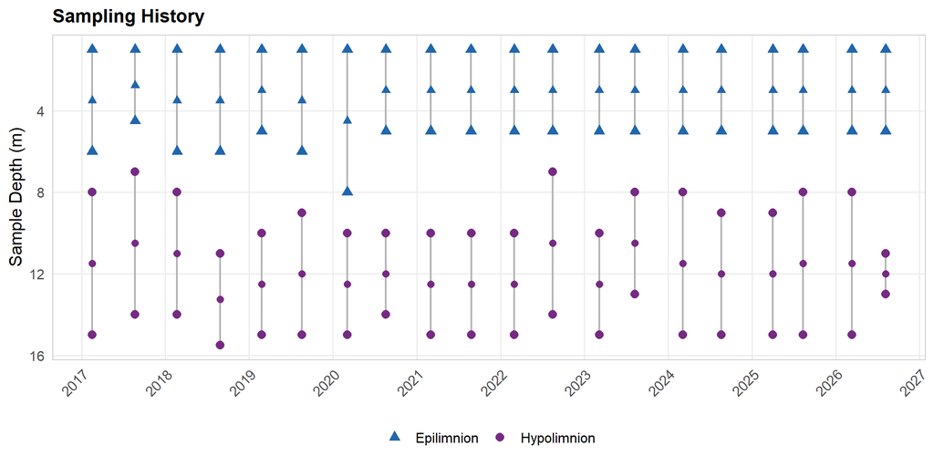

Sampling dates and depth ranges

### Water Quality Trend Summary

The table below gives an at-a-glance summary of every parameter analysed at this site: whether a statistically significant trend (p < 0.05) was detected in each depth/season group, and the applicable BC Aquatic Life guideline. Click a row’s parameter name in the tabs below to see the full plot and history.

**Summary table of trend results**

| Category | Parameter | Epilimnion Spring | Epilimnion Summer | Hypolimnion Spring | Hypolimnion Summer | Guideline |
| --- | --- | --- | --- | --- | --- | --- |
| Field | **Dissolved Oxygen-Field (fl. conc.)** | ▼ 1.1%/yr | ▼ 1.3%/yr | n/a | n/a | ≥ 8 mg/L |
| Field | **Extinction Depth (len.)** | — no trend | — no trend | n/a | n/a | — |
| Field | **Specific Conductivity-Field (elec. cond.)** | ▲ 1.8%/yr | ▲ 2.7%/yr | n/a | n/a | — |
| Field | **Temperature-Field (temp.)** | — no trend | — no trend | n/a | n/a | — |
| Field | **pH-Field (acidity)** | — no trend | — no trend | n/a | n/a | — |
| General | **Carbon Dissolved Organic (fl. conc.)** | — no trend | — no trend | — no trend | — no trend | — |
| General | **Carbon Total Organic (fl. conc.)** | — no trend | — no trend | — no trend | — no trend | — |
| General | **Chlorophyll A (fl. conc.)** | — no trend | — no trend | n/a | n/a | — |
| General | **Specific Conductance (elec. cond.)** | — no trend | ▲ 1.7%/yr | — no trend | — no trend | — |
| General | **Turbidity (turb.)** | — no trend | — no trend | — no trend | — no trend | — |
| General | **pH (acidity)** | ▲ 1.4%/yr | — no trend | ▲ 1.5%/yr | — no trend | — |
| Major Ions | **Chloride Dissolved (fl. conc.)** | — no trend | — no trend | — no trend | — no trend | ≤ 150 mg/L |
| Major Ions | **Hardness Total (Total) (fl. conc.)** | — no trend | ▲ 1.8%/yr | — no trend | — no trend | — |
| Major Ions | **Sulfate Dissolved (fl. conc.)** | — no trend | ▲ 3.9%/yr | ▲ 3.3%/yr | ▲ 7.3%/yr | — |
| Nutrients | **Nitrate (NO3) Dissolved (fl. conc.)** | — no trend | — no trend | — no trend | — no trend | ≤ 3 mg/L |
| Nutrients | **Nitrate(NO3) + Nitrite(NO2) Dissolved (fl. conc.)** | — no trend | — no trend | — no trend | — no trend | — |
| Nutrients | **Nitrogen - Nitrite Dissolved (NO2) (fl. conc.)** | — no trend | — no trend | — no trend | — no trend | — |
| Nutrients | **Nitrogen Ammonia Total (fl. conc.)** | — no trend | — no trend | — no trend | — no trend | — |
| Nutrients | **Nitrogen Kjel.Tot(N) (fl. conc.)** | — no trend | — no trend | — no trend | — no trend | — |
| Nutrients | **Nitrogen Organic-Total (fl. conc.)** | — no trend | — no trend | — no trend | — no trend | — |
| Nutrients | **Nitrogen Total (fl. conc.)** | — no trend | — no trend | — no trend | — no trend | — |
| Nutrients | **Phosphorus Ort.Dis-P (fl. conc.)** | — no trend | — no trend | — no trend | — no trend | — |
| Nutrients | **Phosphorus Total (fl. conc.)** | — no trend | — no trend | — no trend | — no trend | ≤ 15 ug/L |
| Nutrients | **Phosphorus Total Dissolved (fl. conc.)** | — no trend | — no trend | — no trend | — no trend | — |
| Nutrients | **Silica Reactive Diss (fl. conc.)** | — no trend | — no trend | — no trend | — no trend | — |
| Metals - Total | **Aluminum Total (fl. conc.)** | — no trend | ▲ 4.4%/yr | — no trend | — no trend | — |
| Metals - Total | **Antimony Total (fl. conc.)** | — no trend | — no trend | — no trend | — no trend | ≤ 74 ug/L |
| Metals - Total | **Arsenic Total (fl. conc.)** | — no trend | ▼ 4.1%/yr | — no trend | — no trend | ≤ 5 ug/L |
| Metals - Total | **Barium Total (fl. conc.)** | — no trend | — no trend | — no trend | — no trend | ≤ 1 mg/L |
| Metals - Total | **Beryllium Total (fl. conc.)** | — no trend | — no trend | — no trend | — no trend | ≤ 0.13 ug/L |
| Metals - Total | **Bismuth Total (fl. conc.)** | — no trend | — no trend | — no trend | — no trend | — |
| Metals - Total | **Boron Total (fl. conc.)** | — no trend | — no trend | — no trend | — no trend | ≤ 1.2 mg/L |
| Metals - Total | **Cadmium Total (fl. conc.)** | — no trend | — no trend | — no trend | — no trend | — |
| Metals - Total | **Calcium Total (fl. conc.)** | — no trend | ▲ 1.8%/yr | — no trend | — no trend | — |
| Metals - Total | **Chromium Total (fl. conc.)** | — no trend | — no trend | — no trend | — no trend | — |
| Metals - Total | **Cobalt Total (fl. conc.)** | ▼ 10.6%/yr | — no trend | ▼ 9.3%/yr | — no trend | — |
| Metals - Total | **Copper Total (fl. conc.)** | — no trend | ▲ 13.8%/yr | — no trend | — no trend | — |
| Metals - Total | **Iron Total (fl. conc.)** | — no trend | — no trend | — no trend | — no trend | — |
| Metals - Total | **Lead Total (fl. conc.)** | ▼ 20.1%/yr | — no trend | — no trend | — no trend | — |
| Metals - Total | **Lithium Total (fl. conc.)** | — no trend | — no trend | — no trend | — no trend | — |
| Metals - Total | **Magnesium Total (fl. conc.)** | — no trend | ▲ 1.3%/yr | — no trend | ▲ 1.5%/yr | — |
| Metals - Total | **Manganese Total (fl. conc.)** | ▼ 12.4%/yr | — no trend | — no trend | — no trend | — |
| Metals - Total | **Molybdenum Total (fl. conc.)** | — no trend | — no trend | — no trend | — no trend | ≤ 7.6 mg/L |
| Metals - Total | **Nickel Total (fl. conc.)** | — no trend | — no trend | — no trend | — no trend | — |
| Metals - Total | **Potassium Total (fl. conc.)** | — no trend | — no trend | — no trend | — no trend | — |
| Metals - Total | **Selenium Total (fl. conc.)** | — no trend | — no trend | — no trend | — no trend | ≤ 2 ug/L |
| Metals - Total | **Silicon Total (fl. conc.)** | — no trend | — no trend | — no trend | — no trend | — |
| Metals - Total | **Silver Total (fl. conc.)** | — no trend | — no trend | — no trend | — no trend | ≤ 0.12 ug/L |
| Metals - Total | **Sodium Total (fl. conc.)** | — no trend | ▼ 1.8%/yr | — no trend | — no trend | — |
| Metals - Total | **Strontium Total (fl. conc.)** | ▲ 2.1%/yr | — no trend | — no trend | — no trend | — |
| Metals - Total | **Thallium Total (fl. conc.)** | — no trend | — no trend | — no trend | — no trend | ≤ 0.03 ug/L |
| Metals - Total | **Tin Total (fl. conc.)** | — no trend | — no trend | — no trend | — no trend | — |
| Metals - Total | **Uranium Total (fl. conc.)** | ▼ 7.0%/yr | — no trend | — no trend | — no trend | ≤ 7.5 ug/L |
| Metals - Total | **Vanadium Total (fl. conc.)** | — no trend | — no trend | — no trend | — no trend | ≤ 60 ug/L |
| Metals - Total | **Zinc Total (fl. conc.)** | ▼ 6.5%/yr | ▲ 23.6%/yr | — no trend | — no trend | — |

n/a = fewer than 3 samples (or none) in that depth/season group. — no trend = no statistically significant trend, or more than 50% of results were non-detects. Badge colors indicate the *direction* of a detected trend only, not whether that direction is good or bad for water quality.

### Monitoring Results and Trends

Each observation is shown as a black dot in the scatter plots below. Where a statistically significant trend is detected (p < 0.05 with at least 50% of observations above the detection limit), a trend line with 95% confidence bands is displayed and a coloured trend badge is shown on the plot giving the direction and magnitude of the trend. Open orange triangles (▽) indicate non-detects and are plotted at the detection limit.

If a simple water quality guideline (that is one independent of other parameters) applies and measurements are within that guideline a green check box will display showing the guideline value, conversely if a guideline has been exceeded a yellow warning box will be displayed.

Raw data: [EnMoDS Data Search and Download](https://enmodswr.nrs.gov.bc.ca/) | [Water Quality Guidelines](https://www2.gov.bc.ca/gov/content?id=044DD64C7E24415D83D07430964113C9)

#### **Field**

##### Dissolved Oxygen-Field (fl. conc.)

✓

[BC Aquatic Life Guideline](https://www2.gov.bc.ca/gov/content/environment/air-land-water/water/water-quality/water-quality-guidelines/approved-water-quality-guidelines) · Long-term chronic (Lower Limit) Aquatic Life - Freshwater

≥8 mg/L

All Life Stages Other than Buried Embryo / Alevin

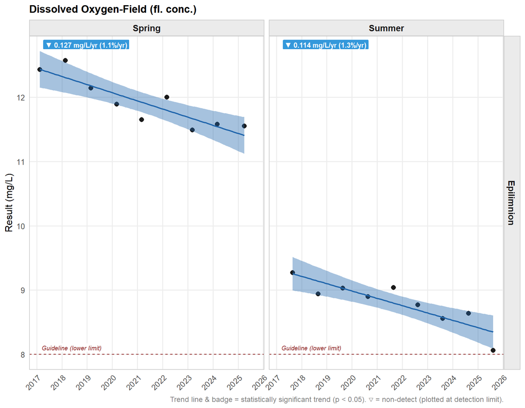

**▶ Summary Statistics Table**

**Lizard Lake**

Dissolved Oxygen-Field (fl. conc.) (mg/L)

| N | Min<sup>1</sup> | 10th %ile | Median | Mean | 90th %ile | Max |
| --- | --- | --- | --- | --- | --- | --- |
| Epilimnion — Summer |  |  |  |  |  |  |
| 9 | 8.06 | 8.46 | 8.9 | 8.8 | 9.09 | 9.27 |
| Epilimnion — Spring |  |  |  |  |  |  |
| 9 | 11.5 | 11.5 | 11.9 | 11.9 | 12.5 | 12.6 |

<sup>1</sup> < indicates non-detect; value shown is the detection limit.

##### Extinction Depth (len.)

—

No simple [BC Aquatic Life Guideline](https://www2.gov.bc.ca/gov/content?id=044DD64C7E24415D83D07430964113C9) available for this parameter

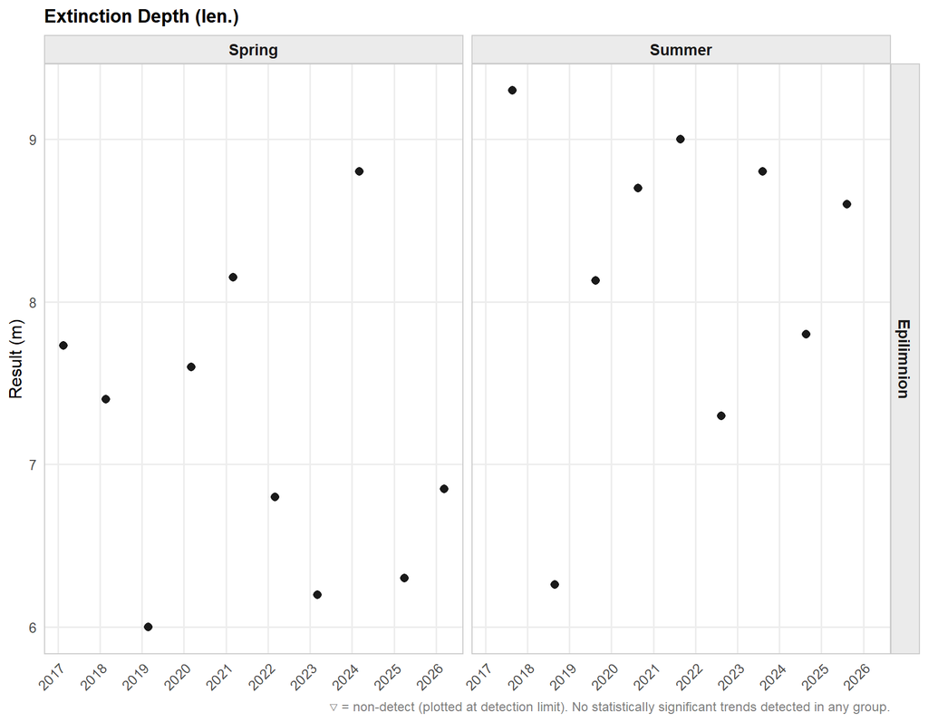

**▶ Summary Statistics Table**

**Lizard Lake**

Extinction Depth (len.) (m)

| N | Min<sup>1</sup> | 10th %ile | Median | Mean | 90th %ile | Max |
| --- | --- | --- | --- | --- | --- | --- |
| Epilimnion — Summer |  |  |  |  |  |  |
| 10 | 6.26 | 6.26 | 8.36 | 8.02 | 9.03 | 9.3 |
| Epilimnion — Spring |  |  |  |  |  |  |
| 11 | 6 | 6.2 | 7.4 | 7.23 | 8.15 | 8.8 |

<sup>1</sup> < indicates non-detect; value shown is the detection limit.

##### pH-Field (acidity)

—

No simple [BC Aquatic Life Guideline](https://www2.gov.bc.ca/gov/content?id=044DD64C7E24415D83D07430964113C9) available for this parameter

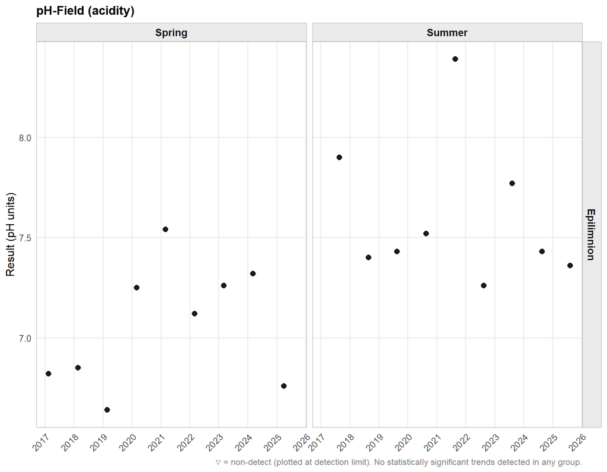

**▶ Summary Statistics Table**

**Lizard Lake**

pH-Field (acidity) (pH units)

| N | Min<sup>1</sup> | 10th %ile | Median | Mean | 90th %ile | Max |
| --- | --- | --- | --- | --- | --- | --- |
| Epilimnion — Summer |  |  |  |  |  |  |
| 9 | 7.26 | 7.34 | 7.43 | 7.61 | 8 | 8.39 |
| Epilimnion — Spring |  |  |  |  |  |  |
| 9 | 6.64 | 6.74 | 7.12 | 7.06 | 7.36 | 7.54 |

<sup>1</sup> < indicates non-detect; value shown is the detection limit.

##### Specific Conductivity-Field (elec. cond.)

—

No simple [BC Aquatic Life Guideline](https://www2.gov.bc.ca/gov/content?id=044DD64C7E24415D83D07430964113C9) available for this parameter

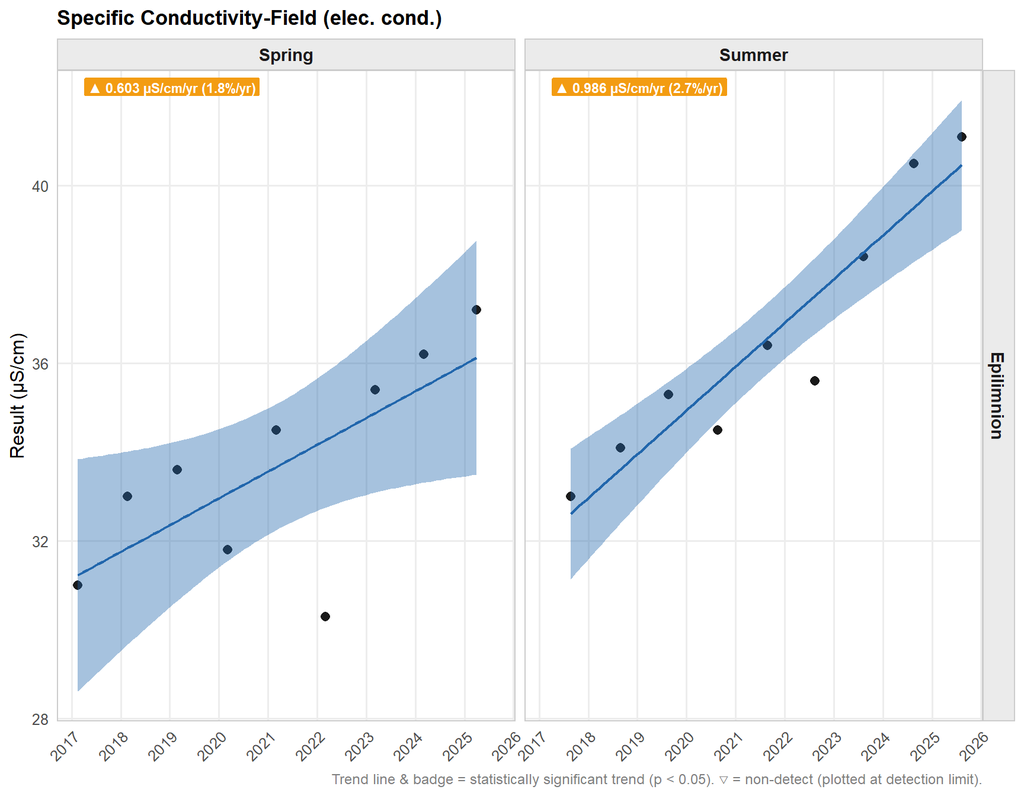

**▶ Summary Statistics Table**

**Lizard Lake**

Specific Conductivity-Field (elec. cond.) (µS/cm)

| N | Min<sup>1</sup> | 10th %ile | Median | Mean | 90th %ile | Max |
| --- | --- | --- | --- | --- | --- | --- |
| Epilimnion — Summer |  |  |  |  |  |  |
| 9 | 33 | 33.9 | 35.6 | 36.5 | 40.6 | 41.1 |
| Epilimnion — Spring |  |  |  |  |  |  |
| 9 | 30.3 | 30.9 | 33.6 | 33.7 | 36.4 | 37.2 |

<sup>1</sup> < indicates non-detect; value shown is the detection limit.

##### Temperature-Field (temp.)

—

No simple [BC Aquatic Life Guideline](https://www2.gov.bc.ca/gov/content?id=044DD64C7E24415D83D07430964113C9) available for this parameter

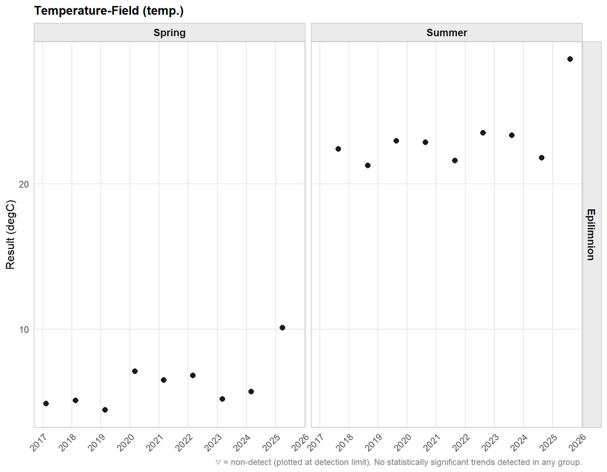

**▶ Summary Statistics Table**

**Lizard Lake**

Temperature-Field (temp.) (degC)

| N | Min<sup>1</sup> | 10th %ile | Median | Mean | 90th %ile | Max |
| --- | --- | --- | --- | --- | --- | --- |
| Epilimnion — Summer |  |  |  |  |  |  |
| 9 | 21.3 | 21.5 | 22.9 | 23.1 | 24.5 | 28.6 |
| Epilimnion — Spring |  |  |  |  |  |  |
| 9 | 4.44 | 4.78 | 5.7 | 6.2 | 7.7 | 10.1 |

<sup>1</sup> < indicates non-detect; value shown is the detection limit.

#### **General**

##### Carbon Dissolved Organic (fl. conc.)

—

No simple [BC Aquatic Life Guideline](https://www2.gov.bc.ca/gov/content?id=044DD64C7E24415D83D07430964113C9) available for this parameter

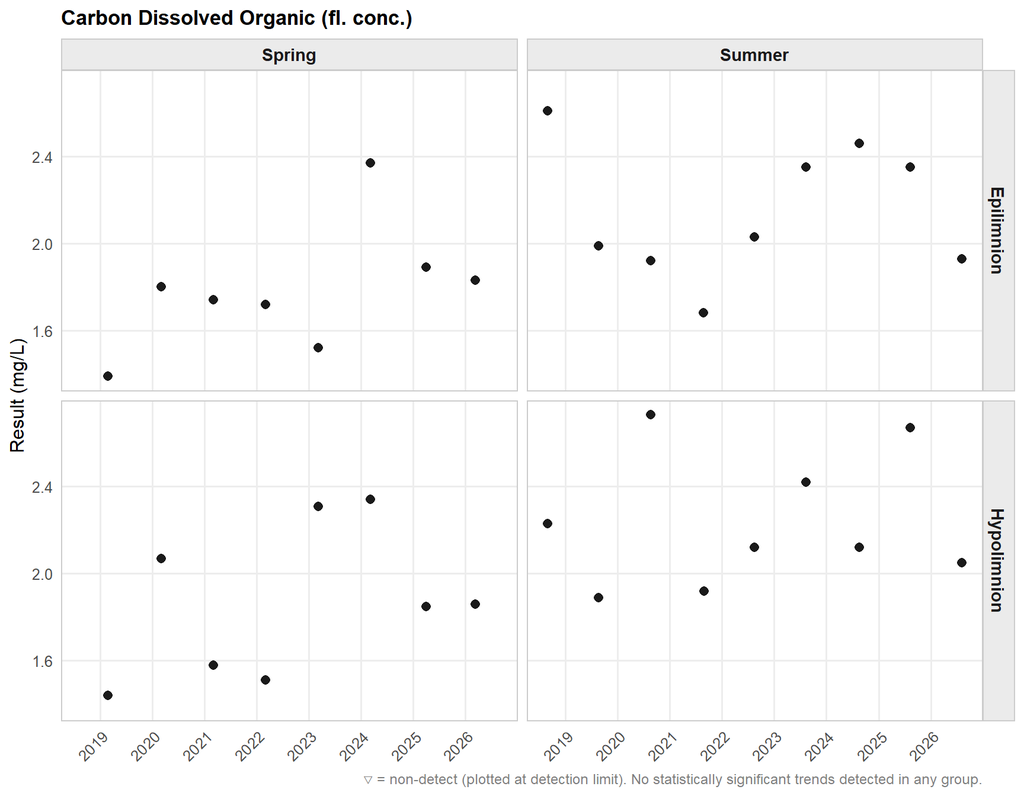

**▶ Summary Statistics Table**

**Lizard Lake**

Carbon Dissolved Organic (fl. conc.) (mg/L)

| N | Min<sup>1</sup> | 10th %ile | Median | Mean | 90th %ile | Max |
| --- | --- | --- | --- | --- | --- | --- |
| Hypolimnion — Summer |  |  |  |  |  |  |
| 9 | 1.89 | 1.91 | 2.12 | 2.24 | 2.68 | 2.73 |
| Hypolimnion — Spring |  |  |  |  |  |  |
| 8 | 1.44 | 1.49 | 1.86 | 1.87 | 2.32 | 2.34 |
| Epilimnion — Summer |  |  |  |  |  |  |
| 9 | 1.68 | 1.87 | 2.03 | 2.15 | 2.49 | 2.61 |
| Epilimnion — Spring |  |  |  |  |  |  |
| 8 | 1.39 | 1.48 | 1.77 | 1.78 | 2.03 | 2.37 |

<sup>1</sup> < indicates non-detect; value shown is the detection limit.

##### Carbon Total Organic (fl. conc.)

—

No simple [BC Aquatic Life Guideline](https://www2.gov.bc.ca/gov/content?id=044DD64C7E24415D83D07430964113C9) available for this parameter

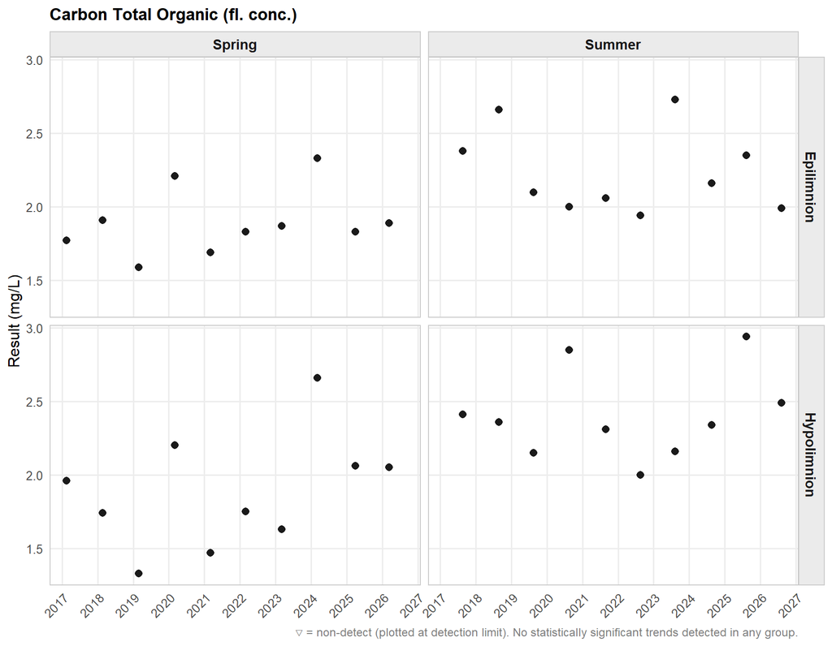

**▶ Summary Statistics Table**

**Lizard Lake**

Carbon Total Organic (fl. conc.) (mg/L)

| N | Min<sup>1</sup> | 10th %ile | Median | Mean | 90th %ile | Max |
| --- | --- | --- | --- | --- | --- | --- |
| Hypolimnion — Summer |  |  |  |  |  |  |
| 10 | 2 | 2.13 | 2.35 | 2.4 | 2.86 | 2.94 |
| Hypolimnion — Spring |  |  |  |  |  |  |
| 10 | 1.33 | 1.46 | 1.86 | 1.88 | 2.25 | 2.66 |
| Epilimnion — Summer |  |  |  |  |  |  |
| 10 | 1.94 | 1.98 | 2.13 | 2.24 | 2.67 | 2.73 |
| Epilimnion — Spring |  |  |  |  |  |  |
| 10 | 1.59 | 1.68 | 1.85 | 1.89 | 2.22 | 2.33 |

<sup>1</sup> < indicates non-detect; value shown is the detection limit.

##### Chlorophyll A (fl. conc.)

—

No simple [BC Aquatic Life Guideline](https://www2.gov.bc.ca/gov/content?id=044DD64C7E24415D83D07430964113C9) available for this parameter

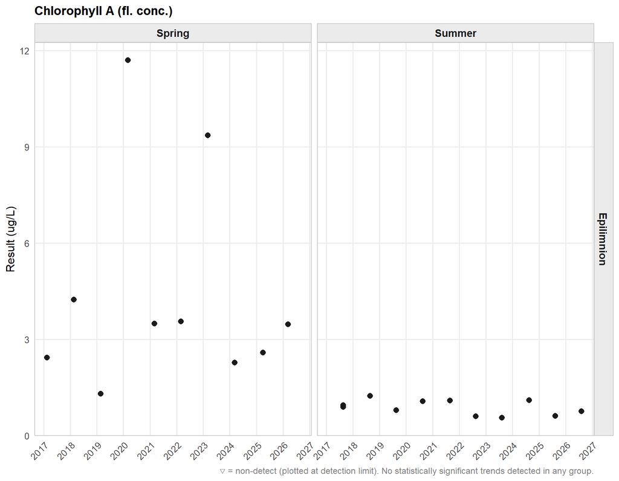

**▶ Summary Statistics Table**

**Lizard Lake**

Chlorophyll A (fl. conc.) (ug/L)

| N | Min<sup>1</sup> | 10th %ile | Median | Mean | 90th %ile | Max |
| --- | --- | --- | --- | --- | --- | --- |
| Epilimnion — Summer |  |  |  |  |  |  |
| 11 | 0.551 | 0.603 | 0.889 | 0.876 | 1.1 | 1.23 |
| Epilimnion — Spring |  |  |  |  |  |  |
| 11 | 1.3 | 2.27 | 3.46 | 4.26 | 9.36 | 11.7 |

<sup>1</sup> < indicates non-detect; value shown is the detection limit.

##### pH (acidity)

—

No simple [BC Aquatic Life Guideline](https://www2.gov.bc.ca/gov/content?id=044DD64C7E24415D83D07430964113C9) available for this parameter

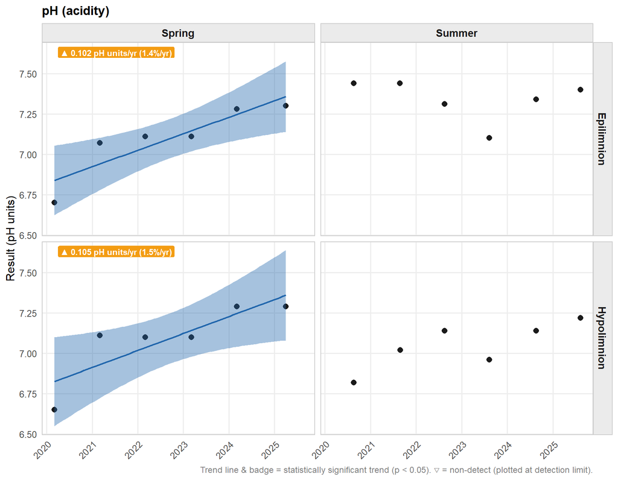

**▶ Summary Statistics Table**

**Lizard Lake**

pH (acidity) (pH units)

| N | Min<sup>1</sup> | 10th %ile | Median | Mean | 90th %ile | Max |
| --- | --- | --- | --- | --- | --- | --- |
| Hypolimnion — Summer |  |  |  |  |  |  |
| 6 | 6.82 | 6.89 | 7.08 | 7.05 | 7.18 | 7.22 |
| Hypolimnion — Spring |  |  |  |  |  |  |
| 6 | 6.65 | 6.88 | 7.1 | 7.09 | 7.29 | 7.29 |
| Epilimnion — Summer |  |  |  |  |  |  |
| 6 | 7.1 | 7.2 | 7.37 | 7.34 | 7.44 | 7.44 |
| Epilimnion — Spring |  |  |  |  |  |  |
| 6 | 6.7 | 6.88 | 7.11 | 7.1 | 7.29 | 7.3 |

<sup>1</sup> < indicates non-detect; value shown is the detection limit.

##### Specific Conductance (elec. cond.)

—

No simple [BC Aquatic Life Guideline](https://www2.gov.bc.ca/gov/content?id=044DD64C7E24415D83D07430964113C9) available for this parameter

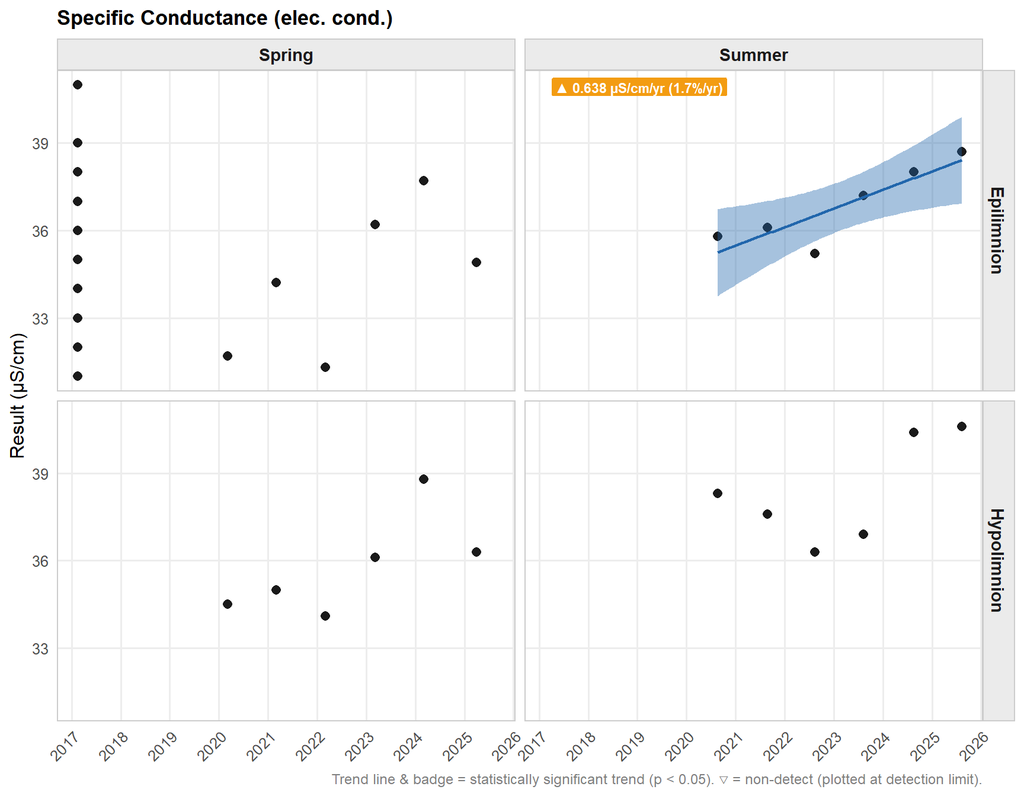

**▶ Summary Statistics Table**

**Lizard Lake**

Specific Conductance (elec. cond.) (µS/cm)

| N | Min<sup>1</sup> | 10th %ile | Median | Mean | 90th %ile | Max |
| --- | --- | --- | --- | --- | --- | --- |
| Hypolimnion — Summer |  |  |  |  |  |  |
| 6 | 36.3 | 36.6 | 38 | 38.4 | 40.5 | 40.6 |
| Hypolimnion — Spring |  |  |  |  |  |  |
| 6 | 34.1 | 34.3 | 35.6 | 35.8 | 37.6 | 38.8 |
| Epilimnion — Summer |  |  |  |  |  |  |
| 6 | 35.2 | 35.5 | 36.7 | 36.8 | 38.4 | 38.7 |
| Epilimnion — Spring |  |  |  |  |  |  |
| 23 | 31 | 31 | 34.2 | 34.5 | 38.8 | 41 |

<sup>1</sup> < indicates non-detect; value shown is the detection limit.

##### Turbidity (turb.)

—

No simple [BC Aquatic Life Guideline](https://www2.gov.bc.ca/gov/content?id=044DD64C7E24415D83D07430964113C9) available for this parameter

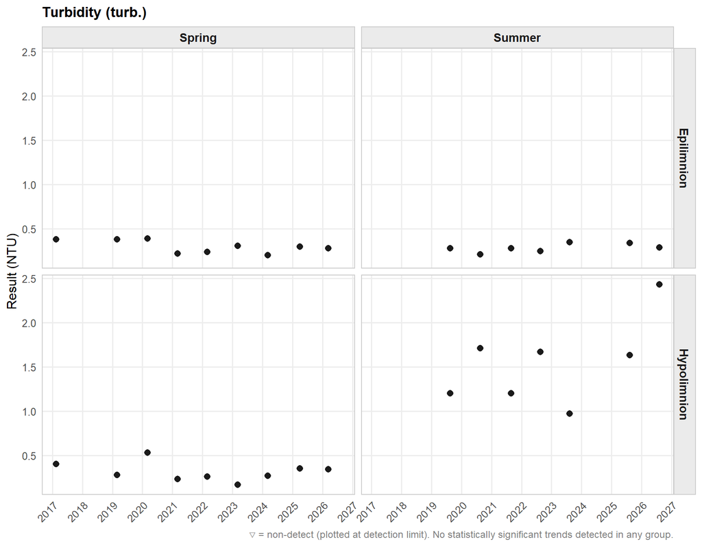

**▶ Summary Statistics Table**

**Lizard Lake**

Turbidity (turb.) (NTU)

| N | Min<sup>1</sup> | 10th %ile | Median | Mean | 90th %ile | Max |
| --- | --- | --- | --- | --- | --- | --- |
| Hypolimnion — Summer |  |  |  |  |  |  |
| 7 | 0.97 | 1.11 | 1.63 | 1.54 | 2 | 2.43 |
| Hypolimnion — Spring |  |  |  |  |  |  |
| 9 | 0.17 | 0.218 | 0.28 | 0.314 | 0.426 | 0.53 |
| Epilimnion — Summer |  |  |  |  |  |  |
| 7 | 0.21 | 0.234 | 0.28 | 0.286 | 0.344 | 0.35 |
| Epilimnion — Spring |  |  |  |  |  |  |
| 9 | 0.2 | 0.216 | 0.3 | 0.3 | 0.382 | 0.39 |

<sup>1</sup> < indicates non-detect; value shown is the detection limit.

#### **Major Ions**

##### Chloride Dissolved (fl. conc.)

✓

[BC Aquatic Life Guideline](https://www2.gov.bc.ca/gov/content/environment/air-land-water/water/water-quality/water-quality-guidelines/approved-water-quality-guidelines) · Long-term chronic (Upper Limit) Aquatic Life - Freshwater

≤150 mg/L

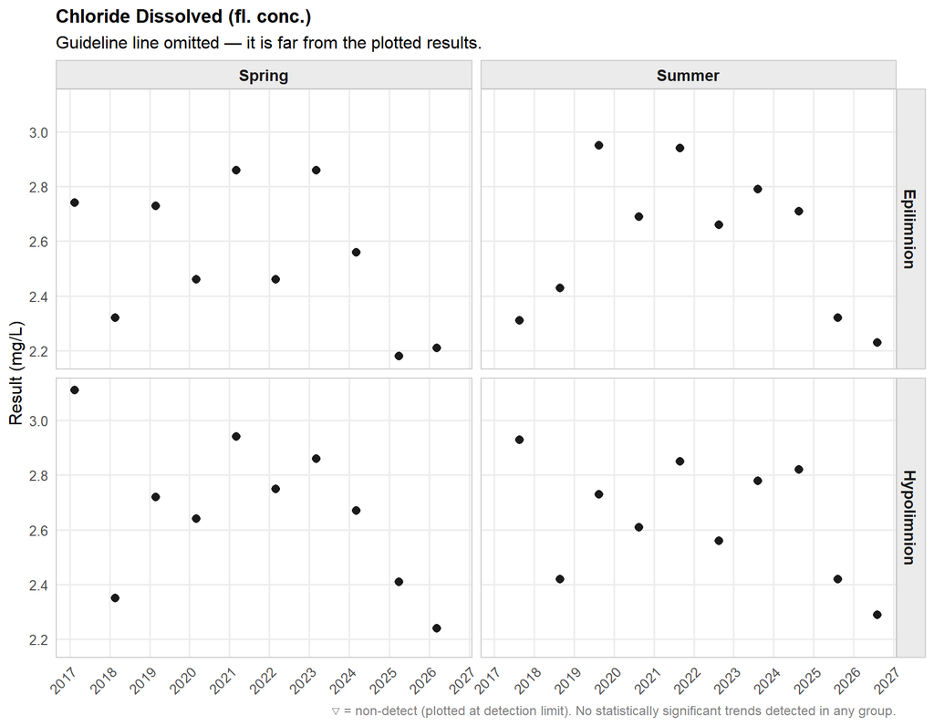

**▶ Summary Statistics Table**

**Lizard Lake**

Chloride Dissolved (fl. conc.) (mg/L)

| N | Min<sup>1</sup> | 10th %ile | Median | Mean | 90th %ile | Max |
| --- | --- | --- | --- | --- | --- | --- |
| Hypolimnion — Summer |  |  |  |  |  |  |
| 10 | 2.29 | 2.41 | 2.67 | 2.64 | 2.86 | 2.93 |
| Hypolimnion — Spring |  |  |  |  |  |  |
| 10 | 2.24 | 2.34 | 2.7 | 2.67 | 2.96 | 3.11 |
| Epilimnion — Summer |  |  |  |  |  |  |
| 10 | 2.23 | 2.3 | 2.68 | 2.6 | 2.94 | 2.95 |
| Epilimnion — Spring |  |  |  |  |  |  |
| 10 | 2.18 | 2.21 | 2.51 | 2.54 | 2.86 | 2.86 |

<sup>1</sup> < indicates non-detect; value shown is the detection limit.

##### Hardness Total (Total) (fl. conc.)

—

No simple [BC Aquatic Life Guideline](https://www2.gov.bc.ca/gov/content?id=044DD64C7E24415D83D07430964113C9) available for this parameter

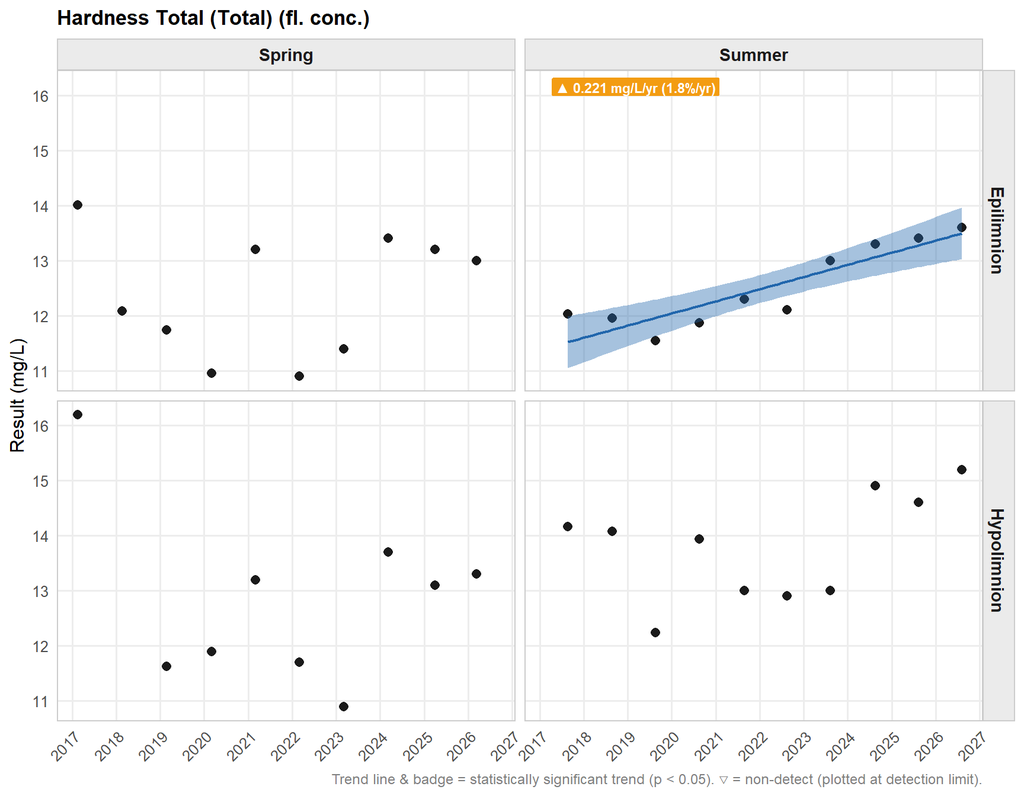

**▶ Summary Statistics Table**

**Lizard Lake**

Hardness Total (Total) (fl. conc.) (mg/L)

| N | Min<sup>1</sup> | 10th %ile | Median | Mean | 90th %ile | Max |
| --- | --- | --- | --- | --- | --- | --- |
| Hypolimnion — Summer |  |  |  |  |  |  |
| 10 | 12.2 | 12.8 | 14 | 13.8 | 14.9 | 15.2 |
| Hypolimnion — Spring |  |  |  |  |  |  |
| 9 | 10.9 | 11.5 | 13.1 | 12.8 | 14.2 | 16.2 |
| Epilimnion — Summer |  |  |  |  |  |  |
| 10 | 11.5 | 11.8 | 12.2 | 12.5 | 13.4 | 13.6 |
| Epilimnion — Spring |  |  |  |  |  |  |
| 10 | 10.9 | 11 | 12.5 | 12.4 | 13.5 | 14 |

<sup>1</sup> < indicates non-detect; value shown is the detection limit.

##### Sulfate Dissolved (fl. conc.)

—

No simple [BC Aquatic Life Guideline](https://www2.gov.bc.ca/gov/content?id=044DD64C7E24415D83D07430964113C9) available for this parameter

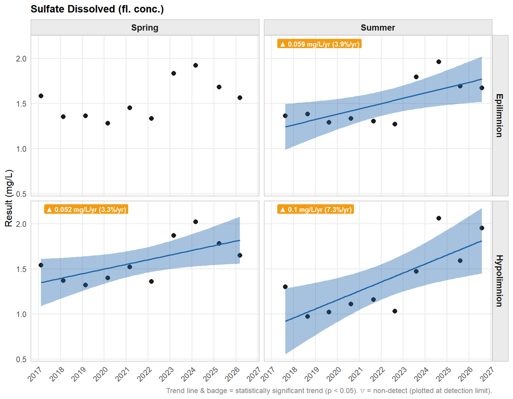

**▶ Summary Statistics Table**

**Lizard Lake**

Sulfate Dissolved (fl. conc.) (mg/L)

| N | Min<sup>1</sup> | 10th %ile | Median | Mean | 90th %ile | Max |
| --- | --- | --- | --- | --- | --- | --- |
| Hypolimnion — Summer |  |  |  |  |  |  |
| 10 | 0.97 | 1.02 | 1.23 | 1.37 | 1.96 | 2.06 |
| Hypolimnion — Spring |  |  |  |  |  |  |
| 10 | 1.32 | 1.36 | 1.53 | 1.58 | 1.88 | 2.02 |
| Epilimnion — Summer |  |  |  |  |  |  |
| 10 | 1.27 | 1.29 | 1.37 | 1.5 | 1.81 | 1.96 |
| Epilimnion — Spring |  |  |  |  |  |  |
| 10 | 1.28 | 1.32 | 1.5 | 1.53 | 1.84 | 1.92 |

<sup>1</sup> < indicates non-detect; value shown is the detection limit.

#### **Nutrients**

##### Nitrate (NO3) Dissolved (fl. conc.)

✓

[BC Aquatic Life Guideline](https://www2.gov.bc.ca/gov/content/environment/air-land-water/water/water-quality/water-quality-guidelines/approved-water-quality-guidelines) · Long-term chronic (Upper Limit) Aquatic Life - Freshwater

≤3 mg/L

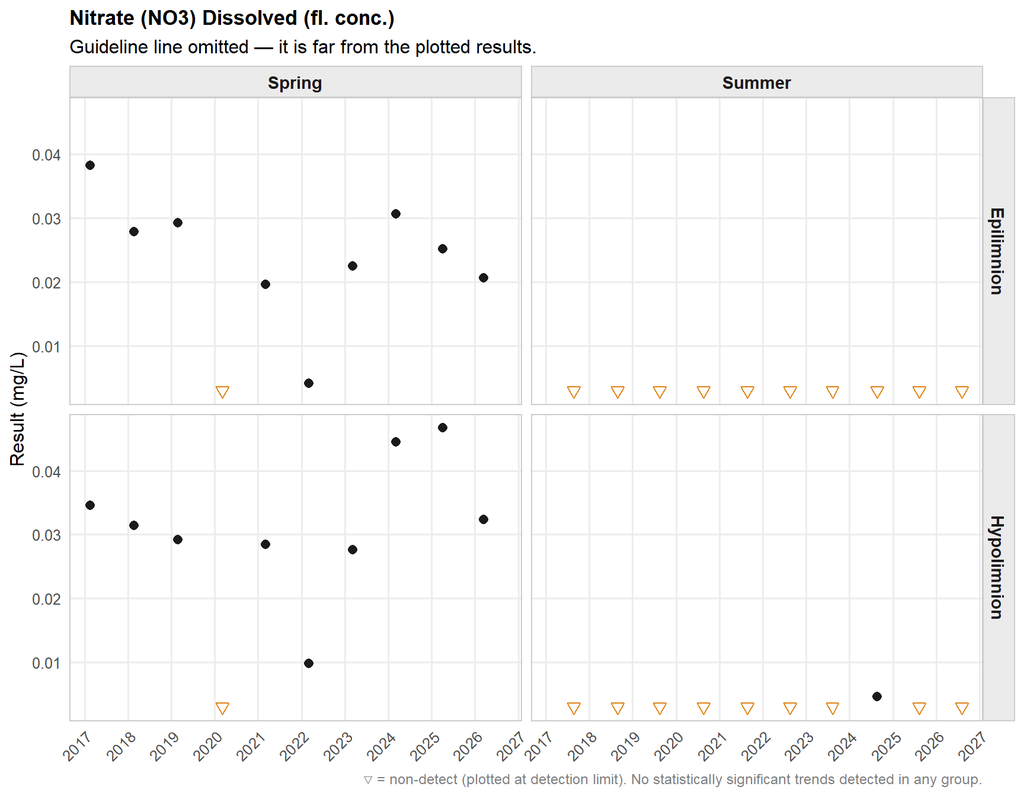

**▶ Summary Statistics Table**

**Lizard Lake**

Nitrate (NO3) Dissolved (fl. conc.) (mg/L)

| N | Min<sup>1</sup> | 10th %ile | Median | Mean | 90th %ile | Max |
| --- | --- | --- | --- | --- | --- | --- |
| Hypolimnion — Summer |  |  |  |  |  |  |
| 10 | <0.003 | <0.003 | <0.003 | 0.00316 | 0.00316 | 0.0046 |
| Hypolimnion — Spring |  |  |  |  |  |  |
| 10 | <0.003 | 0.00912 | 0.0303 | 0.0288 | 0.0447 | 0.0467 |
| Epilimnion — Summer |  |  |  |  |  |  |
| 10 | <0.003 | <0.003 | <0.003 | <0.003 | <0.003 | <0.003 |
| Epilimnion — Spring |  |  |  |  |  |  |
| 10 | <0.003 | 0.00399 | 0.0238 | 0.0221 | 0.0315 | 0.0383 |

<sup>1</sup> < indicates non-detect; value shown is the detection limit.

##### Nitrate(NO3) + Nitrite(NO2) Dissolved (fl. conc.)

—

No simple [BC Aquatic Life Guideline](https://www2.gov.bc.ca/gov/content?id=044DD64C7E24415D83D07430964113C9) available for this parameter

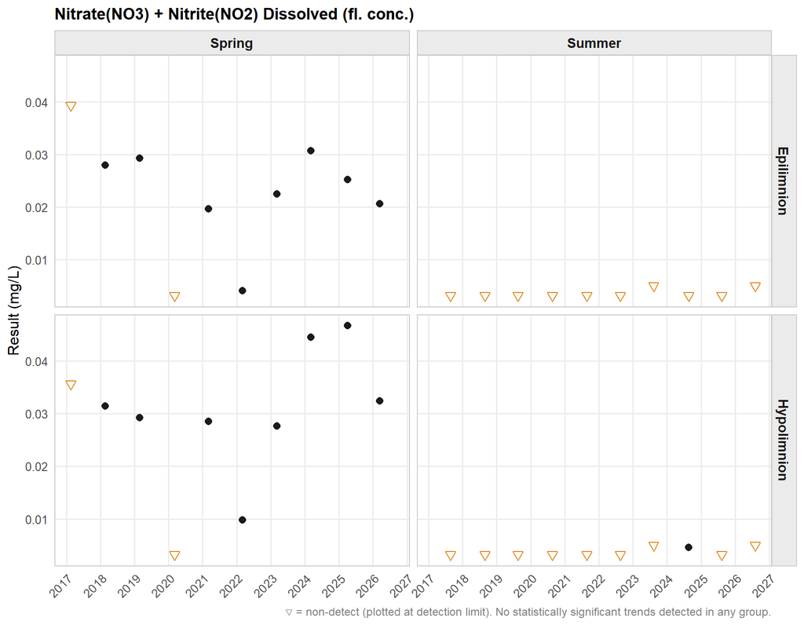

**▶ Summary Statistics Table**

**Lizard Lake**

Nitrate(NO3) + Nitrite(NO2) Dissolved (fl. conc.) (mg/L)

| N | Min<sup>1</sup> | 10th %ile | Median | Mean | 90th %ile | Max |
| --- | --- | --- | --- | --- | --- | --- |
| Hypolimnion — Summer |  |  |  |  |  |  |
| 10 | <0.0032 | <0.0032 | <0.0032 | 0.0037 | 0.005 | 0.005 |
| Hypolimnion — Spring |  |  |  |  |  |  |
| 10 | <0.0032 | 0.00914 | 0.0303 | 0.0289 | 0.0447 | 0.0467 |
| Epilimnion — Summer |  |  |  |  |  |  |
| 10 | <0.0032 | <0.0032 | <0.0032 | 0.00356 | 0.005 | 0.005 |
| Epilimnion — Spring |  |  |  |  |  |  |
| 10 | <0.0032 | 0.00401 | 0.0238 | 0.0222 | 0.0316 | 0.0393 |

<sup>1</sup> < indicates non-detect; value shown is the detection limit.

##### Nitrogen - Nitrite Dissolved (NO2) (fl. conc.)

—

No simple [BC Aquatic Life Guideline](https://www2.gov.bc.ca/gov/content?id=044DD64C7E24415D83D07430964113C9) available for this parameter

0.02 - 0.2 mg/L but varies by site conditions

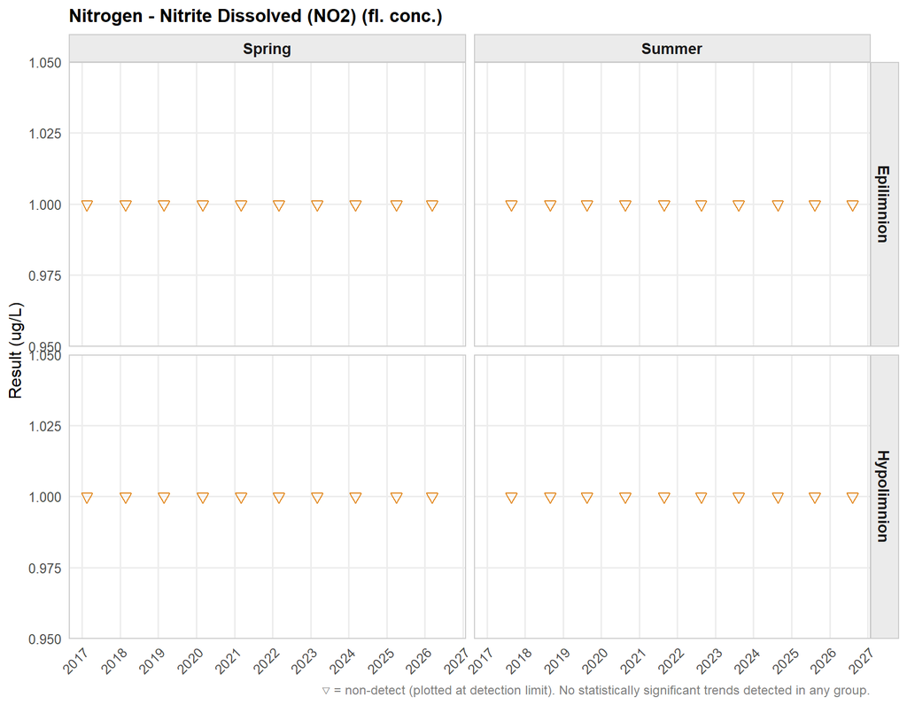

**▶ Summary Statistics Table**

**Lizard Lake**

Nitrogen - Nitrite Dissolved (NO2) (fl. conc.) (ug/L)

| N | Min<sup>1</sup> | 10th %ile | Median | Mean | 90th %ile | Max |
| --- | --- | --- | --- | --- | --- | --- |
| Hypolimnion — Summer |  |  |  |  |  |  |
| 10 | <1 | <1 | <1 | <1 | <1 | <1 |
| Hypolimnion — Spring |  |  |  |  |  |  |
| 10 | <1 | <1 | <1 | <1 | <1 | <1 |
| Epilimnion — Summer |  |  |  |  |  |  |
| 10 | <1 | <1 | <1 | <1 | <1 | <1 |
| Epilimnion — Spring |  |  |  |  |  |  |
| 10 | <1 | <1 | <1 | <1 | <1 | <1 |

<sup>1</sup> < indicates non-detect; value shown is the detection limit.